# MidPoint Deliverable

Winnie Chen

5/25/2020

## Intro

Our group project primarily focuses on unemployment because right now, during this pandemic, unemployment has been at an all time high; however, we want to analyze what other factors could affect unemployment. We analyzed and see how unemployment relates to education, basic demographics, and poverty.

There were several datasets that was used in this project, such as unemployment by state and area, as well as education levels from primary school to Master’s degree. Our project mainly focuses on three dataset: poverty, basic demographics, and education. The poverty dataset compares how poverty is spread throughout the U.S., allowing us to examine the relationship between unemployment and poverty and see what states and counties have the highest prevalence. As for the education and basic demographics dataset, it contains the unemployment rate based on the education qualification of adults and race.

## Summary Information

In 2018, the mean percent of adults living in a given county in the U.S. without a highschool diploma was 13.74%, while the mean percent of adults with a bachelor’s degree or more was 21.57%. The average unemployment rate and poverty rate for U.S. counties were 4.3% and 15.16% respectively. The county with the lowest poverty rate had 2.6% of its population living in poverty, while the county with the highest poverty rate had 54% of its population living in poverty.

## Average Unemployment Rate With Different Levels of Education

| Year | No Diploma | Only High School | Some College | Bachelors Degree |
| --- | --- | --- | --- | --- |
| 2010 | 14.84 | 10.29 | 8.38 | 4.71 |
| 2011 | 14.07 | 9.43 | 7.97 | 4.31 |
| 2012 | 12.39 | 8.31 | 7.10 | 4.03 |
| 2013 | 10.96 | 7.51 | 6.37 | 3.70 |
| 2014 | 9.02 | 6.01 | 5.42 | 3.17 |
| 2015 | 7.94 | 5.44 | 4.51 | 2.57 |
| 2016 | 7.43 | 5.19 | 4.08 | 2.51 |
| 2017 | 6.51 | 4.65 | 3.75 | 2.32 |
| 2018 | 5.61 | 4.04 | 3.32 | 2.12 |
| 2019 | 5.35 | 3.66 | 3.02 | 2.09 |

This table shows the average unemployment rate across months for the years 2010 to 2019, seperated by level of education. We added this table to be able to easily see the differences in average unemployment rate between adults living in the U.S. with different levels of education.

## Chart 1: Unemployment vs Poverty

The purpose of this graph is to show the correlation between the unemployment of each state and the number of people in poverty. Each dot represents a state and their unemployment rate and how that affects the people in poverty. A scatter plot would be the best plot for this type of data since it makes it easy for the user to see how it correlates with each other.

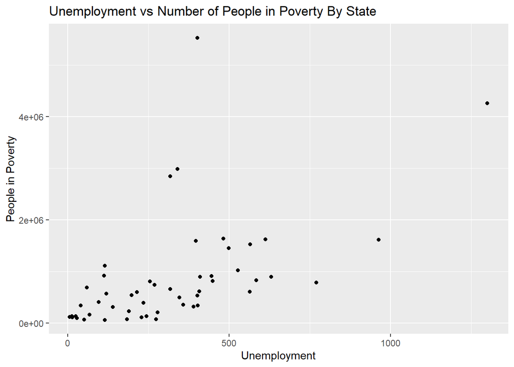

This chart reveals that there’s a positive correlation between unemployment and people in poverty. The lower the unemployment, the lower the number of people in poverty. It also shows that many states don’t have high unemployment and people in poverty, however, there are no states that has exactly zero. In addition, we see a few outliers in the chart, two specifically that are way out of line with the rest of the states. Regardless of the two outliers, we can see that there is a positive correlation between unemployment and people in poverty.

## Chart 2: Unemployment vs Education Level

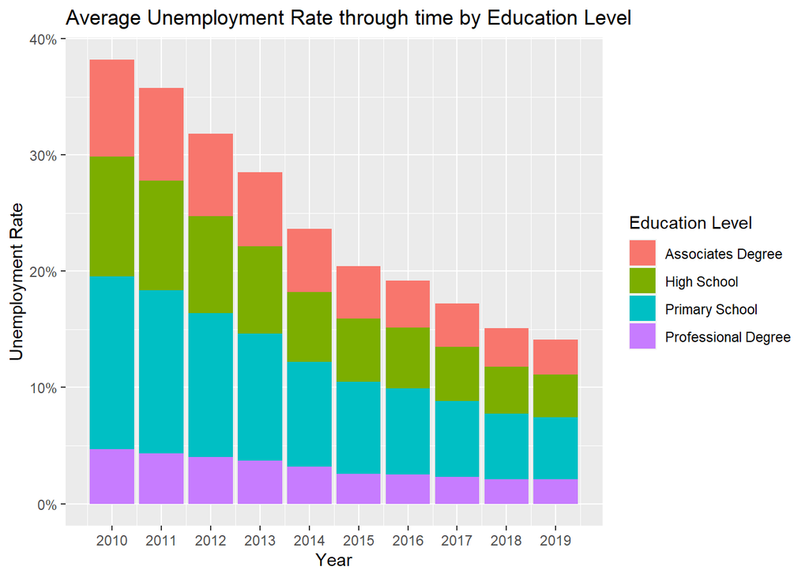

I included this stacked bar chart because it compares the unemployment rates of each education level by year. This is easier to see the differences. The chart reveals the average unemployment rate for each education level by year. One thing I observed from this was that the discrepancy between a primary school education level and a professional school education level got smaller as the years passed. In addition, the chart descended as the years passed, which means that unemployment levels decreased.

## Chart 3: Unemployment Demographics

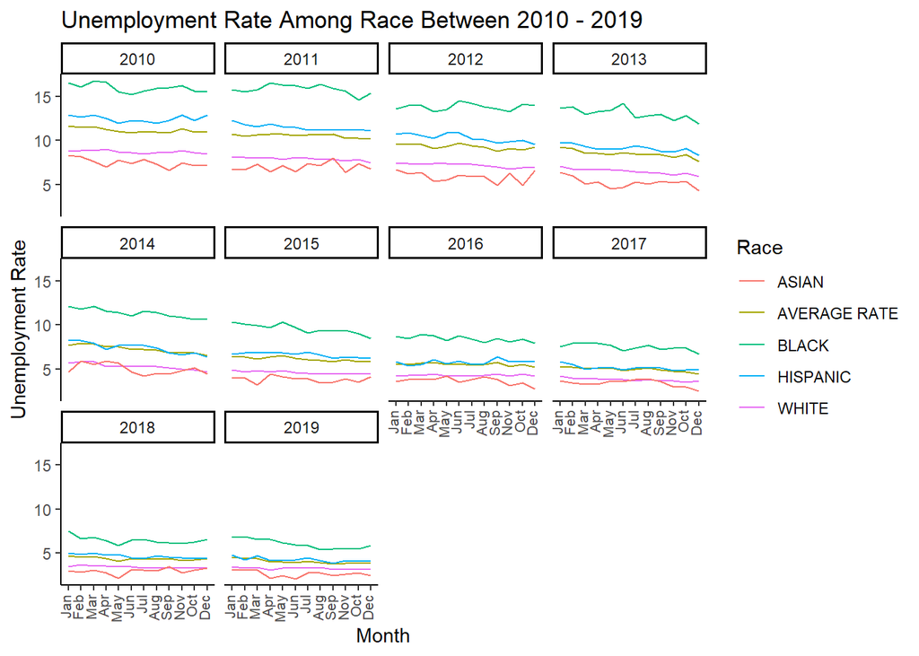